3D'omics · AlberdiLab · practical

# Where do gut bacteria actually live?

Micro-scale spatial metagenomics: measuring the microbiome of a chicken gut at a resolution of a few hundred micrometres — and testing whether what we find is really structured in space.

336

microsamples, from two cryosections

223

bacterial genomes quantified in each

5,000 µm²

tissue per microsample

The question

> Bacteria in the gut are not randomly mixed. Do communities a few hundred micrometres apart differ *systematically* — and can we say which bacteria sit at each end of the gradient?

Conventional metagenomics cannot ask this. Homogenising a caecum destroys every spatial relationship in it before sequencing begins. To ask *where*, the sample has to stay intact and be taken apart under a microscope.

The data

## Every community profile carries a position

### Per microsample

Community composition — which of the 223 genomes, and how much of each.  
X, Y position on the tissue.  
Distance to the gut wall.  
Sequencing depth and diversity.

### Per genome

Taxonomy and genome size.  
Position in the bacterial phylogeny.  
Metabolic capacity, as pathway completeness.

Two sides of the same dataset. Almost everything in this practical is an attempt to **link them**: what is where, and what kind of bacterium that is.

### Two cryosections, one animal

G121eI117A — caecum, 168 microsamples  
G121eO306A — colon, 168 microsamples  
Same chicken, so region differences are not confounded with individual.

Study design

[figure not shown]

Step 3, and why it matters

## MSSM does not pool libraries equimolarly

### Standard metagenomics

Quantify each library, pool equimolarly.  
Every sample receives roughly equal reads.  
**Depth is a nuisance** — deliberately equalised, and any residual variation is something to correct for.

### MSSM

Equal tissue area, equal PCR cycles, pooled as they come. One cryosection per sequencing run.  
**Depth is a measurement** — reads track the DNA that went in, and therefore the microbial biomass.

5,000 µm²

identical area, every microsample

15

PCR cycles, every library

419×

depth spread, caecum section

1,366×

depth spread, colon section

Two caveats. Depth is a *share* of one run, so it is relative within a cryosection and never comparable across them — which is why every analysis stays inside one section. And it is a proxy: extraction and PCR efficiency vary, and deeper sequencing detects more, so richness inherits both signals.

Chapter 1 · from mapping output to a community table

## Count coverage, not reads

At face value, nearly every genome in the catalogue appears in nearly every microsample — a median of 222 of 223. That cannot be real for a fragment of tissue this small.

Mapping is a heuristic: reads from a genome that *is* present also align, imperfectly, to its relatives. Those stray reads scatter across the wrong genome instead of covering it evenly.

**So ask how much of the genome was covered, not how many reads arrived.** Breadth of coverage is strongly bimodal, which is what makes a threshold defensible.

### Filtering at 30 % breadth

70 %

of non-zero entries removed

92.6 %

of reads kept

### Read that pairing again

The filter discards most *cells* and almost no *reads*. What it removes was near-empty to begin with — the rare tail that was mostly mapping noise.

Chapter 1 · a confound you cannot remove

## Richness rides on sequencing depth

Spearman ρ = 0.94 in the caecum, 0.93 in the colon, between richness and log sequencing depth.

Two mechanisms produce that, and this dataset cannot separate them:

- bioA microsample with more biomass genuinely holds more genomes.
- techA microsample sequenced more deeply detects more of whatever it holds.

**Both are real. Neither can be switched off.** Any claim resting on richness alone is on thin ice.

### Why this is not fatal

Because of the pooling protocol, depth is not a nuisance to be regressed away — it is a biological variable in its own right.

The analysis in Chapter 3 does not try to remove it. It gives it an axis of its own, so that the other axes can be read cleanly.

Chapter 2 · testing for spatial structure

## Two questions the raw table mixes together

### How much was there?

Sequencing depth. Under this protocol, a stand-in for biomass.  
Set aside here, deliberately — and picked up again in Chapter 3 as its own variable.

### What was it made of?

Genuinely compositional: within a microsample only the *ratios* between genomes are interpretable.  
Handled with a centred log-ratio transform — divide by the microsample's geometric mean, then take logs.

Note what CLR does to the total: it **divides it out entirely**. That is the right move for asking what lives somewhere, and it is exactly why the biomass signal has to be reintroduced separately later.

Chapter 2 · first real result

## Local variation dwarfs the difference between organs

### PERMANOVA · caecum vs colon

3.1 %

of variance explained by gut region

p = 0.001

highly significant, and tiny

Two different organs, and the difference between them accounts for a thirtieth of the variation in the data. The other 97 % is variation *between neighbouring microsamples within a single section*.

### The case for micro-scale sampling

Homogenise a caecum and you average away almost everything that is going on inside it.

It also tells us where to work: inside one cryosection, where gut region, animal and laboratory batch are all held constant and only position varies.

Chapter 2 · PERMANOVA inside one cryosection

## Distance to the gut wall explains nothing

Aitchison distance ~ predictor, 999 permutations

| Section | Predictor | R² | F | p |
| --- | --- | --- | --- | --- |
| caecum | distance to gut wall | 0.009 | 1.43 | 0.076 |
| caecum | X + Y coordinates | 0.022 | 1.78 | 0.005 |
| caecum | log sequencing depth | 0.051 | 8.73 | 0.001 |
| colon | distance to gut wall | 0.007 | 1.11 | 0.277 |
| colon | X + Y coordinates | 0.017 | 1.34 | 0.096 |
| colon | log sequencing depth | 0.115 | 20.3 | 0.001 |

But it does mean any spatial gradient has to be looked for *underneath* the biomass signal.

Chapter 2 · spatial autocorrelation

## Moran's I — a correlation coefficient for space

Microsamples are not on a grid, so "nearby" is defined by a **Gabriel graph**: two microsamples are joined when no third lies inside the circle having them as its diameter.

Caecum section G121eI117A

| Variable | I | p |
| --- | --- | --- |
| distance to gut wall | 0.56 | <0.001 |
| sequencing depth | 0.14 | 0.003 |
| richness | 0.01 | 0.375 |
| composition (PCA axis 1) | 0.001 | 0.447 |

### A result in its own right

Sequencing depth is spatially autocorrelated. Read as biomass, that means **microbial biomass is patchy at the sub-millimetre scale** — neighbouring pieces of tissue tend to be densely or sparsely colonised together.

### And a puzzle

Richness correlates with depth at ρ > 0.9, yet is spatially flat. Two variables can be tightly correlated and still behave differently in space.

Chapter 2 · the turning point

## PCA ranks axes by variance, not by relevance

CLR-PCA of the caecum section — what each axis actually corresponds to

| Axis | variance | ρ depth | ρ gut-wall dist. | Moran's I | p |
| --- | --- | --- | --- | --- | --- |
| PC1 | 13.4 % | −0.14 | 0.10 | 0.001 | 0.447 |
| PC2 | 8.2 % | 0.77 | 0.02 | 0.184 | <0.001 |
| PC3 | 6.4 % | 0.02 | 0.21 | 0.146 | 0.002 |

Chapter 3 · extended RLQ

## Ask for covariance, not variance

Stop looking for the axis with the most variance. Look for the axis along which **what we know about microsamples** and **what we know about genomes** covary. Neither noise nor biomass can fake that: there is no reason for a microsample's DNA yield to correlate with what its bacteria can metabolise.

E

environment

depth ≈ biomass, richness, distance to gut wall

S

space

Gabriel neighbour graph of microsample positions

L

community

genome counts, Hellinger-transformed

T

traits

metabolic capacity (GIFT), ordinated

P

phylogeny

patristic distances on the MAG tree

Classical RLQ links three tables — environment, community, traits. The extended version (Pavoine et al. 2011) adds space and phylogeny. Two axes carry 86 % of the co-inertia here.

Chapter 3 · never interpret an axis before checking it

## One axis is biomass. One is the gradient.

Spearman ρ between RLQ site scores and the variables in table E

| Section | Variable | axis 1 | axis 2 |
| --- | --- | --- | --- |
| caecum | sequencing depth | 0.93 | −0.30 |
| caecum | richness | 0.95 | −0.37 |
| caecum | distance to gut wall | −0.11 | 0.48 |
| colon | sequencing depth | 0.94 | 0.60 |
| colon | distance to gut wall | −0.03 | 0.01 |

### Axis 1 — biomass

In both sections. Because pooling was unnormalised, this is a biological gradient, not an artefact — and RLQ has put it on an axis of its own.

### Caecum axis 2 — the gradient

Tracks distance to the gut wall, and only weakly tracks depth. The colon shows nothing spatial — an honest negative result.

Chapter 3 · caecum section G121eI117A

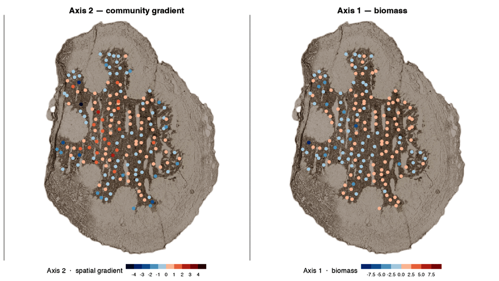

## Two spatial patterns in one piece of tissue

Axis 2 forms a coherent band running across the section. Axis 1 is patchier and locally clustered — which is what a biomass map should look like.

Moran's I on the RLQ axes

| Axis | I | p |
| --- | --- | --- |
| caecum axis 1 | 0.097 | 0.027 |
| caecum axis 2 | 0.166 | 0.0007 |
| colon axis 1 | 0.038 | 0.214 |
| colon axis 2 | 0.021 | 0.312 |

Chapter 3 · what sits at each end

## Reading the gradient

|  | Near the gut wall | Out in the lumen |
| --- | --- | --- |
| Axis 2 score | low | high |
| Genome size | smaller | larger ρ = 0.42 |
| Metabolism | relatively more lipid-oriented | more polysaccharide degradation ρ = 0.75 |
| Taxa | Erysipelotrichales, Lactobacillales, Coriobacteriales | Lachnospirales, UBA1381 |

### A coherent story

Complex plant polysaccharides arrive in the lumen, and degrading them needs large gene repertoires. Close to the epithelium the substrates are host-derived instead, and the bacteria there are smaller and differently equipped.

### Inherited, too

Blomberg's *K* = 1.52, p = 0.001. Closely related genomes sit at the same end of the gradient more than a random walk along the tree would produce — spatial preference is phylogenetically conserved.

What to take away

### 2 · A protocol decision made the result findable

Because libraries were pooled without normalisation, biomass entered the analysis as a measured variable instead of hiding inside the composition. Under equimolar pooling the differences would have been flattened — while the variation they cause stayed in the community table, unlabelled and inseparable from the gradient.

### 3 · Negative results are results

The colon section shows no gradient. One animal, one section per region, a modest R². The honest version of this analysis reports all of that.

Now your turn

## The exercises

- 1**The coverage filter.** Rebuild the table at 0, 0.1, 0.3 and 0.6. Does the conclusion survive?
- 2**Compositionality.** Does anything of the total survive CLR? What follows for detecting a biomass gradient?
- 3**Spatial structure.** Swap the Gabriel graph for k-nearest-neighbours. Should the answer change?
- 4**RLQ.** Drop distance to the gut wall from table E and re-run. If the gradient survives, it was not an artefact of telling the method what to look for.
- 5**Interpretation.** Genome size and polysaccharide capacity are correlated. Separate them.
- 6**Extension.** A reviewer insists on equimolar pooling. Write the reply.

### Exercise 4.1 is the one that matters

Everything in Chapter 3 rests on RLQ having found a gradient rather than having been handed one. That exercise is the test.

Credits

## The study behind the practical

Carlotta Pietroni†, Bryan Wang†, Amalia Bogri†, Jorge Langa, Iñaki Odriozola, Zoé Horisberger, Marta Contreras-Serrano, Jonas Greve Lauritsen, Nanna Gaun, Amalia Toffano, Anders Miki Bojesen, Ida Thøfner, Victoria Drauch, Jaime Ramirez Cerrillos, Søren Johannes Sørensen, Urvish Trivedi*, Antton Alberdi*.  
*Micro-scale spatial metagenomics: revealing high-resolution spatial biogeography of gut microbiomes.*  
doi.org/10.1101/2025.09.30.679663  
† equal contribution · * corresponding authors

### This is a simplified version

The practical was extracted from the study's original analysis repository and cut down to what fits a course session — validation, benchmarking and strain-level work are not included here.

### The original analysis

github.com/3d-omics/MSSM  
FISH and macro-scale cross-validation, genome-catalogue comparison, contamination assessment, strain-level microdiversity, six-cryosection replication.

Carried out within 3D'omics (Horizon 2020). Manuscript under review in PNAS.